# W3cubDocs

## Viewing and regenerating recovery code

**Note:** Once you regenerate a set of code, all previous recovery codes become invalid. Each code can be used only once.

1. [Log in](https://www.npmjs.com/login) to npm with your user account.

2. In the upper right corner of the page, click your profile picture, then click **Account**.

3. On the account settings page, under "Two-Factor Authentication", click **Modify 2FA**.

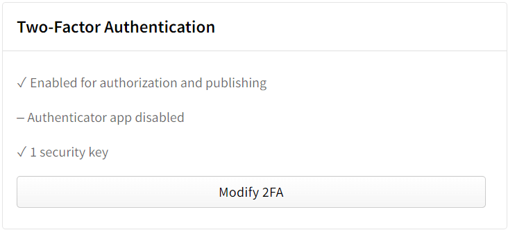

4. Click "Manage Recovery Codes'' to view your recovery codes

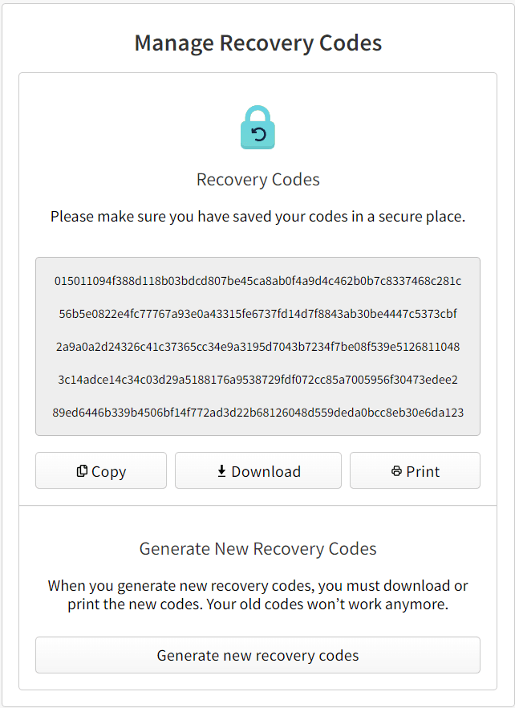

## Misplaced recovery codes

If you have misplaced both the device that provided second-factor authentication and your recovery codes, we may be unable to help you recover your account. If you have any questions, please [contact npm Support](https://www.npmjs.com/support).